# Group Project - Section D Group 4

## Introduction

For our project, we considered crime data in Denver going back to 2019. Looking at the data, we wanted to see if the proportion of theft crimes in relation to all crimes are higher in summer months than winter months. We also wanted to see if graffiti crimes are equally likely to happen across different time periods of the day.

## Is the proportion of theft crimes in relation to all crimes higher in summer months than winter months?

To manipulate the data in the given dataset, we mutate the data to create a new column in the dataset titled “seasons”, in which every crime committed in June, July, August, and September are categorized into summer months and every crime committed in December, January, February, and March are categorized into winter months. We then mutate the data to create a new column which differentiates whether a crime is theft or not.

We determine our hypothesis using these new proportions, where p1 is the proportion of summer theft crimes compared to total summer crimes and p2 is the proportion of winter theft crimes compared to total winter crimes.

H0: p1 = p2

Ha: p1 > p2

We visualized the data by creating a stacked bar chart with the proportion of theft crimes compared to all crimes stacked under the proportion of all other crimes compared to all crimes for both summer and winter. It appears that the proportion of theft crimes compared to all crimes is approximately the same regardless of the season being summer or winter. After performing a prop.test of the data, we get a p-value of 0.500. Based on this p-value, we fail to reject the null hypothesis and therefore we do not have sufficient enough evidence to conclude that the proportion of theft crimes in relation to all crimes is higher in summer months than winter months.

## Are graffiti crimes equally likely to happen across different time periods of the day?

To manipulate the data we mutated the section “hour” to make 6 different groups into its own column. We used the filter function to only select graffiti crimes and get rid of the rest of crimes. The na.omit function was then used to get rid of all the inputs that had NA in them. It is now possible to perform a chi squared test. We used the modified columns to find the chi squared test statistic.

We can now determine our hypothesis tests from the chi squared test statistic:

H0: Graffiti crimes are not associated with time of day

Ha: Graffiti crimes are associated with time of day

## Figures

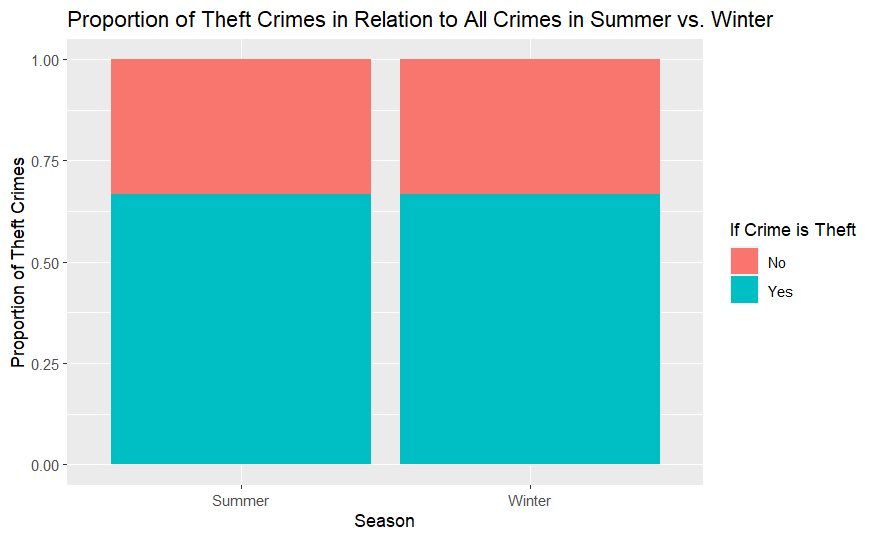

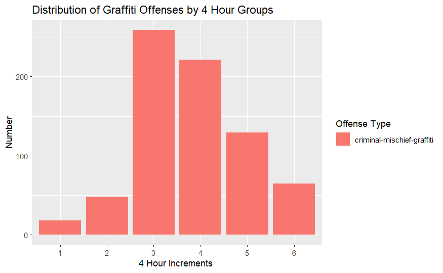

# Appendix

```r
prop.test(seasons~theftcrimes, alternative= "greater", data=RawDataQuestion1, success = "Summer")
```

```
    2-sample test for equality of proportions with continuity correction

data:  tally(seasons ~ theftcrimes)
X-squared = 1.4356e-06, df = 1, p-value = 0.5005
alternative hypothesis: greater
95 percent confidence interval:
 -0.007869742  1.000000000
sample estimates:
   prop 1    prop 2
0.5311715 0.5312220
```

```r
xchisq.test(HourInc ~ offense_type_id, data = RawDataQuestion2)
```

```
    Chi-squared test for given probabilities

data:  x
X-squared = 390.4, df = 5, p-value < 2.2e-16

   18       48      259      221      129       65
(123.33) (123.33) (123.33) (123.33) (123.33) (123.33)
[ 89.96] [ 46.01] [149.23] [ 77.34] [  0.26] [ 27.59]
<-9.48>  <-6.78>  <12.22>  < 8.79>  < 0.51>  <-5.25>

key:
    observed
    (expected)
    [contribution to X-squared]
    <Pearson residual>
```